# week_7_resume

[figure not shown]

**Специализация "Машинное обучение и анализ данных"**

**ФИНАЛЬНЫЙ ПРОЕКТ**

**"Идентификация интернет-пользователей"**

Выполнил: Попович И.Б.

# Вводная часть

В этом проекте сделана попытка решить задачу идентификации пользователя по его поведению в сети Интернет. По последовательности из нескольких веб-сайтов, посещенных подряд один и тем же человеком, пытаемся идентифицировать этого человека. Идея в том, пользователи Интернета по-разному переходят по ссылкам, и это может помогать их идентифицировать.

Для анализа используются данные с прокси-серверов Университета Блеза Паскаля. Для каждого пользователя заведен csv-файл с названием user**.csv (где вместо звездочек – 4 цифры, соответствующие ID пользователя), а в нем посещения сайтов записаны в следующем формате:

*timestamp, посещенный веб-сайт*

На решение задачи было отведено 6 недель, тематический план следующий:

- Подготовка данных к анализу
- Первичный анализ
- Визуализация и постороение дополнительных признаков
- Сравнение моделей классификации
- Соревнование по идентификации пользователей [(Kaggle InClass)](https://www.kaggle.com/c/catch-me-if-you-can-intruder-detection-through-webpage-session-tracking2)
- Применение Vowpal Wabbit

Далее сгруппируем тематический план в две главы:

# Подготовка и анализ данных

Ниже приведен пример исходных данных. В таблице последовательно фиксируется момент времени обращения к каждому сайту. Исходные данные были представлены в виде файлов csv для каждого пользователя.

|  | timestamp | site |
| --- | --- | --- |
| 0 | 2013-11-15 08:12:07 | fpdownload2.macromedia.com |
| 1 | 2013-11-15 08:12:17 | laposte.net |
| 2 | 2013-11-15 08:12:17 | www.laposte.net |
| 3 | 2013-11-15 08:12:17 | www.google.com |
| 4 | 2013-11-15 08:12:18 | www.laposte.net |

## Подготовка данных

Первым этапом следовало представить данные в формате, подходящем для обучения. Для этого была написана процедура, реализующая следующие шаги:

- подготовка справочника сайтов с присвоением им кодов на основании частот встречаемости в логах пользователей
- подготовка единой таблицы для всех пользователей, где посещенные сайты сгруппированы в сессии по 10 последовательно посещенных, и закодированы в соответсвии со справочником сайтов

Фрагмент обучающей выборки:

| site1 | site2 | site3 | site4 | site5 | site6 | site7 | site8 | site9 | site10 | user_id |
| --- | --- | --- | --- | --- | --- | --- | --- | --- | --- | --- |
| 3 | 2 | 2 | 7 | 2 | 1 | 8 | 5 | 9 | 10 | 1 |
| 3 | 1 | 1 | 1 | 0 | 0 | 0 | 0 | 0 | 0 | 1 |
| 3 | 2 | 6 | 6 | 2 | 0 | 0 | 0 | 0 | 0 | 2 |
| 4 | 1 | 2 | 1 | 2 | 1 | 1 | 5 | 11 | 4 | 3 |
| 4 | 1 | 2 | 0 | 0 | 0 | 0 | 0 | 0 | 0 | 3 |

Далее процедура была усовершенствована - добавлена возможность изменять длину сессии и применять скользящее окно (включать в каждую последующую сессию некоторую часть предыдущей)

###### Коды процедур

```python
# подготовка выборки из сессий по 10 сайтов
def prepare_train_set(path_to_csv_files, session_length=10):

    f_list = glob(os.path.join(path_to_csv_files, '*.csv'))
    data = []
    users = {}

    # готовим общий список сайтов по всем пользователям (data)
    # и список пользователей с количеством записей в логах (users)
    for i in tqdm_notebook(range(len(f_list)), desc='reading', unit = 'user'):
        user_id = int(f_list[i].split('\\')[-1].split('.')[0][-4:])
        user_sites = [sites[1].rstrip() for sites in
                      [file.split(',') for file in open(f_list[i])][1:]
                     ]
        data.extend(user_sites)
        users[user_id] = len(user_sites)

    # готовим словарь вида {site: number_visits}
    dict_counter = dict.fromkeys(data, 0)
    for i in tqdm_notebook(data, desc='creating dict', unit = 'rec', unit_scale=True):
        dict_counter[i] += 1

    # сортируем словарь по количеству посещений
    dict_counter = sorted(dict_counter.items(), key=lambda x: x[1], reverse=True)

    # кодируем сайты порядковыми номерами {site: (code, number_visits)}
    site_freq = dict(zip([x[0] for x in dict_counter],
                         enumerate([x[1] for x in dict_counter], start=1)))

    #### собираем матрицу сессий ####
    start = 0 # начальная позиция записей текущего пользователя в data
    shift = 0 # сдвиг для записи в итоговую таблицу
    # размеры итоговой матрицы: n - строки, m - столбцы
    n = int(sum(np.ceil(np.array([x[1] for x in users.items()])/session_length)))
    m = session_length + 1
    res = np.zeros(n * m, dtype='int32').reshape(n, m) # заготовка итоговой матрицы

    # для каждого пользователя выстаскиваем его записи
    for user in tqdm_notebook(users.items(), desc='creating matrix', unit = 'user'):
        end = start + user[1] # конечная позиция записей текущего пользователя в data
        user_sites = data[start:end] # записи текущего пользователя

        # делим на группы по заданной длине сессии
        for i in range(int(np.ceil(len(user_sites)/session_length))):
            sess = user_sites[i * session_length: (i + 1) * session_length]
            sites_id = [site_freq[x][0] for x in sess]
            # проверяем хватает ли данных; дополняем нулями, если нет
            if len(sites_id) == session_length:
                sites_id.append(user[0])
            else:
                sites_id.extend([0]*(session_length - len(sites_id)))
                sites_id.append(user[0])
            res[shift + i] = sites_id
        # наращиваем стартовые позиции в data и в res для следующего пользователя
        start = end
        shift = shift + int(np.ceil((user[1])/session_length))

    # преобразуем результат в DataFrame (формат по условию)
    res = pd.DataFrame(res)
    res.columns = [x[0] + str(x[1])
                   for x in zip(['site'] * session_length, range(1, session_length + 1))
                  ] + ['user_id']

    return res, site_freq
```

```python
# процедура с возможностью указания размера скользящего окна
def prepare_sparse_train_set_window(path_to_csv_files, site_freq_path,
                                    session_length=10, window_size=10):

    f_list = glob(os.path.join(path_to_csv_files, '*.csv'))
    data = []
    users = {}
    # загружаем справочник кодов и частот сайтов
    with open(site_freq_path, 'rb') as site_freq_pkl:
        site_freq = pickle.load(site_freq_pkl)

    # готовим общий список сайтов по всем пользователям (data)
    # и список пользователей с количеством записей в логах (users)
    for i in tqdm_notebook(range(len(f_list)), desc='reading', unit = 'user'):
        user_id = int(f_list[i].split('\\')[-1].split('.')[0][-4:])
        user_sites = [sites[1].rstrip() for sites in
                      [file.split(',') for file in open(f_list[i])][1:]
                     ]
        data.extend(user_sites)
        users[user_id] = len(user_sites)

    #### собираем матрицу сессий ####
    start = 0 # начальная позиция записей текущего пользователя в data
    shift = 0 # сдвиг для записи в итоговую таблицу
    # размеры итоговой матрицы: n - строки, m - столбцы
    n = int(sum(np.ceil(np.array([x[1] for x in users.items()])/window_size)))
    m = session_length + 1
    res = np.zeros(n * m, dtype='int32').reshape(n, m) # заготовка итоговой матрицы

    # для каждого пользователя выстаскиваем его записи
    for user in tqdm_notebook(users.items(), desc='creating matrix', unit = 'user'):
        end = start + user[1] # конечная позиция записей текущего пользователя в data
        user_sites = data[start:end] # записи текущего пользователя

        # делим на группы по заданной длине сессии
        for i in range(int(np.ceil(len(user_sites)/window_size))):
            sess = user_sites[i * window_size: i  * window_size + session_length]
            sites_id = [site_freq[x][0] for x in sess]
            # проверяем хватает ли данных; дополняем нулями, если нет
            if len(sites_id) == session_length:
                sites_id.append(user[0])
            else:
                sites_id.extend([0]*(session_length - len(sites_id)))
                sites_id.append(user[0])
            res[shift + i] = sites_id
        # наращиваем стартовые позиции в data и в res для следующего пользователя
        start = end
        shift = shift + int(np.ceil((user[1])/window_size))

    # преобразуем результат в DataFrame (формат по условию)
    res = pd.DataFrame(res)
    res.columns = [x[0] + str(x[1])
                   for x in zip(['site'] * session_length, range(1, session_length + 1))
                  ] + ['user_id']

    X, y = res.iloc[:, :-1].values, res.iloc[:, -1].values
    X_sparse = csr_matrix(
        (np.ones(X.size, dtype='int8'),
         X.ravel(),
         range(0, X.size + session_length, session_length)
        ))[:,1:]

    return X_sparse, y
```

## Визуализация и построение признаков

Далее мы визуализировали признаки и анализировали поведение пользователей. Эксперименты проводили на выборке из 10-ти пользователей, которым дали имена.

### Примеры графиков

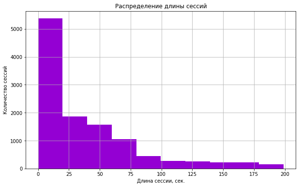

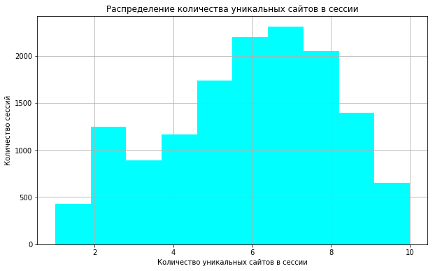

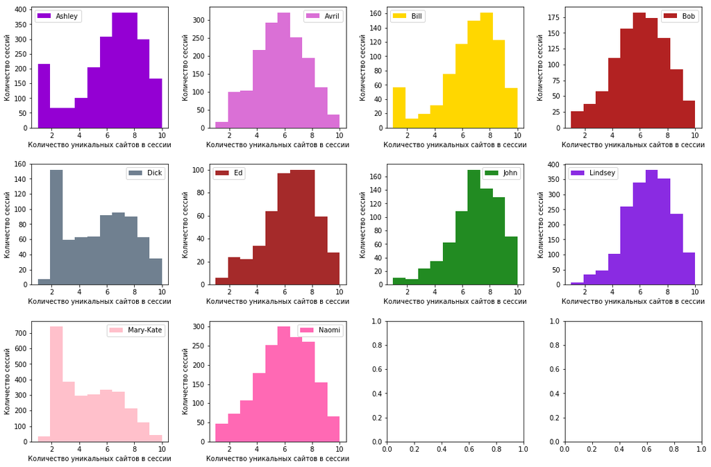

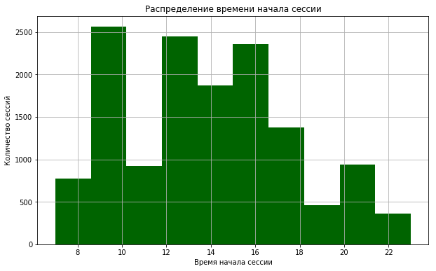

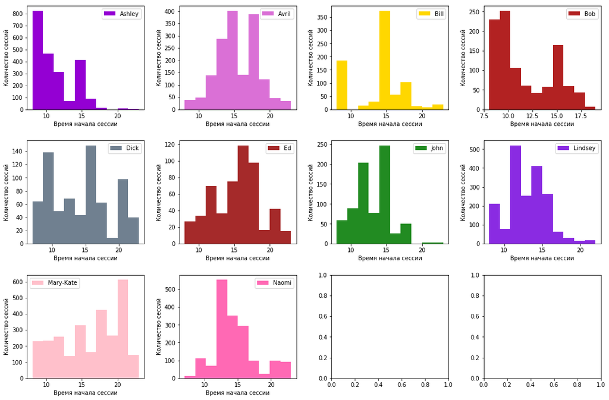

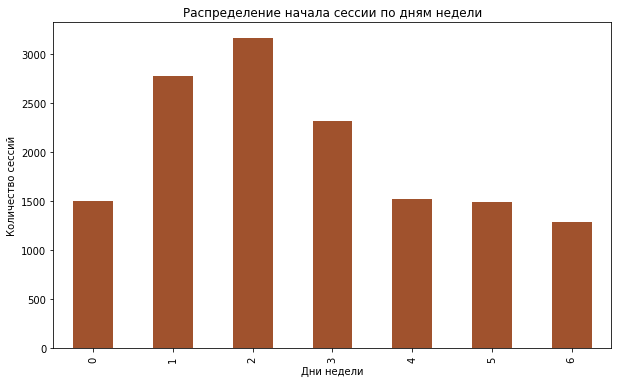

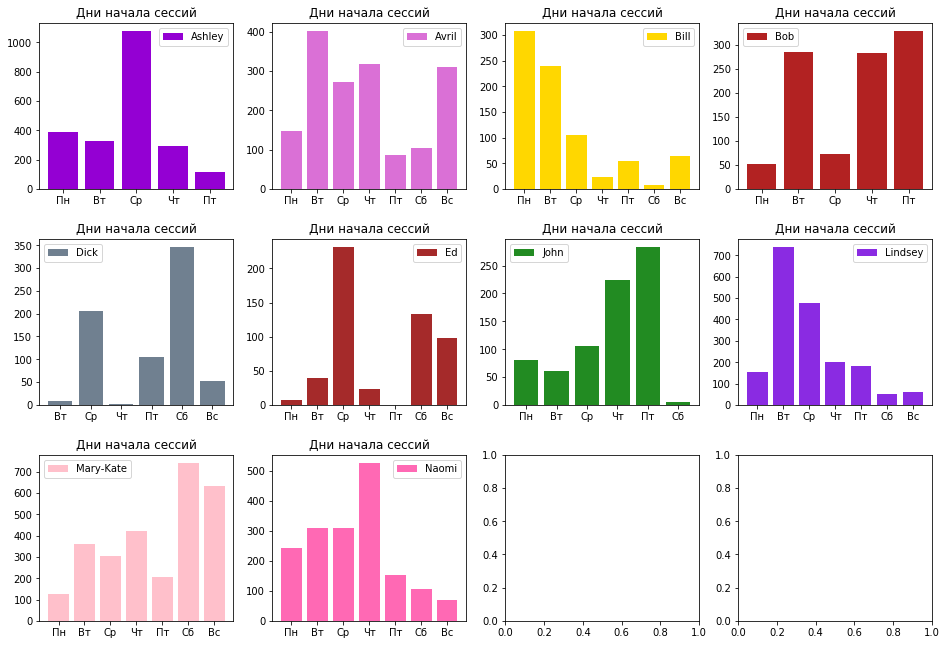

### Выводы по визуальному анализу

По визуальному анализу были сделаны следующие выводы:

**Ashley** - у Эшли рекорд по "залипанию" на одном сайте на всю сессию (200 сессий из одного сайта). Она ранняя птичка - рекордсмен по количеству сессий в первой половине дня. После 16 часов активность сходит на нет. Наибольшую активность проявляет по средам, но и в остальные будние дни не бездействует. В выходные в интернет не выходила ни разу (не начата ни одна сессия).

**Avril** - по количеству уникальных в сессии из 10-ти сайтов распределение похоже на нормальное. По началу сессии пики активности в 14-15 и 17-18 часов; до 11 и после 20 активность невысокая. По дням недели невысокая активность во понедельник, пятницу, субботу и довольно-таки высокая в воскресенье, что не типично в анализируемом наборе.

**Bill** - по количеству уникальных в сессии из 10-ти сайтов пик находится в районе 6-9, но есть всплеск на треть пикового значения в единице. По началу сессии пики активности в 9 и 15 часов, в остальное время - существенно меньше В течение недели количество сессий идет на спад, от пика в понедельник. В пятницу и воскресенье есть небольшое увеличение активности

**Bob** - по количеству уникальных в сессии из 10-ти сайтов распределение похоже на нормальное, с креном в сторону больших значений. По количеству сессий наибольшая активность до обеда и в 15 часов. Наименее активен в понедельник и среду, в остальные дни примерно равная активность. В выходные активности нет.

**Dick** - разнообразие частенько ограничивается 2-мя сайтами. Пики использования по часам: 9, 16, 20. Один из немногих активных пользователей после 20 часов. В понедельник в интернете не бывает; очень мало во вторник и четверг. Пики активности - суббота и среда

**Ed** - по уникальности распределени смещено в сторону большого разнообразия. Пик активности в течение дня - 15-19 часов. Наибольшая активность по дням: среда, суббота, воскресенье

**John** - по уникальности распределени смещено в сторону большого разнообразия. Пик активности в течение дня в 12 и 15 часов. После 18 активности практически нет. В течение недели активность возрастает, с небольшим провалом во вторник, к пику в пятницу. В субботу актичность незначительна, в воскресенье - отсутствует.

**Lindsey** - по уникальности распределени смещено в сторону большого разнообразия. Наибольшая активность в течение дня в 11-16 часов. После 16 постепенно сходит на нет. По дням максимальная активность во вторник и среду, минимальная - в выходные

**Mary-Kate** - По уникальности сайтов в сессии ее распределение похоже на распределение Дика, т.е. она тоже частенько за сессию просматривает не более двух сайтов. По другим показателям она выбивается из среднего. Активность в течение дня нарастает, и пика достигает после 20 часов.По дням недели активность также нетипична - максимум на выходных. Ну, и количество сессий (а значит записей в логе) у нее максимальное.

### Построение новых признаков

**Были добавлены следующие признаки:**

- top_1 - top_10 - индикаторы вхождения сайта в топ-30
- season - время года
- times_of_day - время суток
- year - год
- month - месяц
- day - день

Ниже фрагмент полученной выборки

|  | site1 | site2 | site3 | site4 | site5 | site6 | site7 | site8 | site9 | site10 | time_diff1 | time_diff2 | time_diff3 | time_diff4 | time_diff5 | time_diff6 | time_diff7 | time_diff8 | time_diff9 | top_1 | top_2 | top_3 | top_4 | top_5 | top_6 | top_7 | top_8 | top_9 | top_10 | … |
| --- | --- | --- | --- | --- | --- | --- | --- | --- | --- | --- | --- | --- | --- | --- | --- | --- | --- | --- | --- | --- | --- | --- | --- | --- | --- | --- | --- | --- | --- | --- |
| 0 | 192 | 574 | 133 | 3 | 133 | 133 | 3 | 133 | 203 | 133 | 10 | 0 | 0 | 1 | 20 | 1 | 0 | 1 | 0 | 0 | 0 | 0 | 1 | 0 | 0 | 1 | 0 | 0 | 0 | … |
| 1 | 415 | 193 | 674 | 254 | 133 | 31 | 393 | 3305 | 217 | 55 | 1 | 0 | 163 | 105 | 0 | 1 | 3 | 3 | 8 | 0 | 0 | 0 | 0 | 0 | 0 | 0 | 0 | 0 | 0 | … |
| 2 | 55 | 3 | 55 | 55 | 5 | 293 | 415 | 333 | 897 | 55 | 0 | 14 | 1 | 242 | 0 | 0 | 1 | 0 | 0 | 0 | 1 | 0 | 0 | 1 | 0 | 0 | 0 | 0 | 0 | … |
| 3 | 473 | 3306 | 473 | 55 | 55 | 55 | 55 | 937 | 199 | 123 | 2 | 1 | 0 | 1 | 25 | 1 | 0 | 0 | 0 | 0 | 0 | 0 | 0 | 0 | 0 | 0 | 0 | 0 | 0 | … |
| 4 | 342 | 55 | 5 | 3307 | 258 | 211 | 3308 | 2086 | 675 | 2086 | 1 | 0 | 1 | 1 | 1 | 0 | 1 | 1 | 0 | 0 | 0 | 1 | 0 | 0 | 0 | 0 | 0 | 0 | 0 | … |

[interactive chart not shown]

Утром к сайтам из топ-30 обращаются меньше всего. Днем показатели стабильно средние, а к вечеру проявляются рекордсмены Эта комбинация показателей будет полезна для идентификации, т.к. по многим пользователям показатель "подвижен" и часто "разнонаправлен". Например, Дик активен с утра, и его активность в течение дня падает, а Джон с утра вялый, но к вечеру активизируется. А Мери-Кейт вообще не устает! )

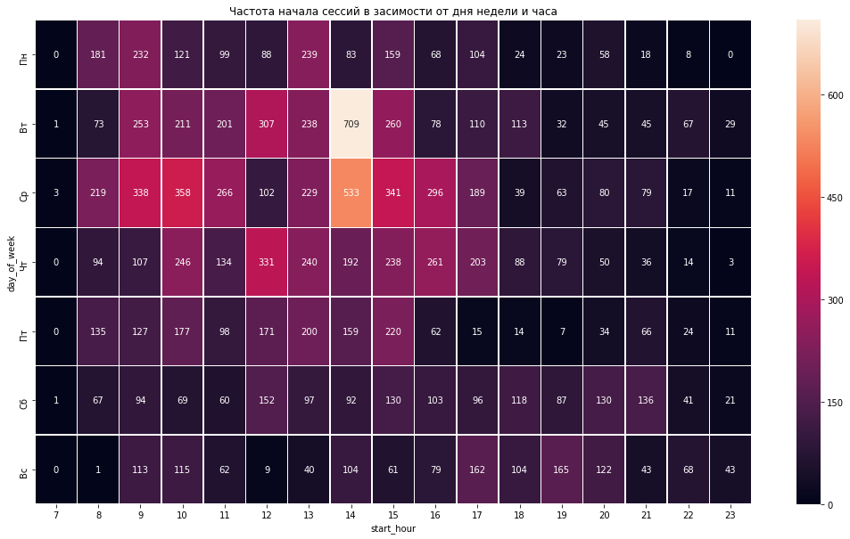

Анализ частоты начала сессий показал, что наибольшая активность приходится на дневное время середины недели. Пик приходится на послеобеденное время вторника и среды

# Построение моделей классификации

## Сравнение классификаторов

В этой части работы сначала были опробованы различные классификаторы на выборке из 10-ти пользователей (многоклассовая классификация):

- KNeighborsClassifier
- RandomForestClassifier
- LogisticRegression
- LinearSVC

Лучший результат был у LinearSVC. С использованием этого классификатора было проведено сравнение результатов прогнозирования на выборках с различными длинами сессий и размерами окон. Ниже приведен результат:

```
длина сессии - 15, размер окна - 10, CV-accuracy - 0.824, accuracy - 0.840, время - 3.03
длина сессии - 10, размер окна - 10, CV-accuracy - 0.765, accuracy - 0.781, время - 2.26
длина сессии - 15, размер окна -  7, CV-accuracy - 0.848, accuracy - 0.854, время - 3.71
длина сессии - 10, размер окна -  7, CV-accuracy - 0.797, accuracy - 0.807, время - 2.52
длина сессии -  7, размер окна -  7, CV-accuracy - 0.753, accuracy - 0.762, время - 2.04
длина сессии - 15, размер окна -  5, CV-accuracy - 0.868, accuracy - 0.875, время - 4.50
длина сессии - 10, размер окна -  5, CV-accuracy - 0.816, accuracy - 0.825, время - 3.15
длина сессии -  7, размер окна -  5, CV-accuracy - 0.774, accuracy - 0.785, время - 2.43
длина сессии -  5, размер окна -  5, CV-accuracy - 0.725, accuracy - 0.736, время - 2.08
```

Лучший результат получился при длине сессии - 15 и размере окна - 5. Эта комбинация дает максимальный размер обучающей выборки, что благоприятно сказывается на результате. При этом, с точки зрения комбинирования этих параметров, выгодно чтобы длина сессии была больше, т.к. это дает больше признаков для каждого объекта выборки. Таким образом, комбинация длины сессии - 15 и размера окна - 5 дает максимальный объем выборки и максимальный набор признаков для каждого объекта выборки

Далее выполняли проверку для выборки из 150-ти пользователей. Качество прогноза при этом значительно упало, т.к. тут класификация уже на 150 классов. Измеряли результат при сотношении сессии и окна 5х5, 7х7 и 10х10. Здесь лучший результат у варианта 10х10:

```
длина сессии -  5, размер окна -  5, CV-accuracy - 0.409, accuracy - 0.422, время - 240.47
длина сессии -  7, размер окна -  7, CV-accuracy - 0.436, accuracy - 0.453, время - 211.05
длина сессии - 10, размер окна - 10, CV-accuracy - 0.461, accuracy - 0.484, время - 168.48
```

Несмотря на то, что выборка в этом варианте самая маленькая, количество признаков на объект сыграло решающую роль.

## Бинарная классификация (соревнование)

Самая интересная часть финального проекта, на мой взгляд, - это соревнование [Catch me if you can](https://www.kaggle.com/c/catch-me-if-you-can-intruder-detection-through-webpage-session-tracking2). В работе использовался SGDClassifier. Последовательность действий была следующая:

1. Работа с признаками
   - Применение TF-IDF к идентификаторам сайтов
   - Добавление новых признаков
2. Параметризация SGDClassifier
   - Выбор параметров для поиска по сетке на заданной обучающей выборке
3. Подготовка собственных выборок
   - Изменение ширины окна
   - Ограничение максимальной продолжительности сессии

### Работа с признаками

К таблице с последовательностями сайтов в сесcии был применен TF-IDF, что позволяет сделать акцент на сайтах, посещение которых характерно для конкретного пользователя.

Было добавлено четыре дополнительных признака:

- день недели начала сессии
- час начала сессии
- количество уникальных сайтов в сессии
- продолжительность сессии

Категориальные реквизиты, а ими оказались все, кроме продолжительности сессии, были переведены в разреженный формат [csr_matrix](https://docs.scipy.org/doc/scipy-0.18.1/reference/generated/scipy.sparse.csr_matrix.html). Продолжительность сессии стандартизирована при помощи [StandardScaler](http://scikit-learn.org/stable/modules/generated/sklearn.preprocessing.StandardScaler.html)

### Параметризация SGDClassifier

Для выбора лучших параметров использовался поиск по сетке [GridSearchCV](http://scikit-learn.org/stable/modules/generated/sklearn.model_selection.GridSearchCV.html). Первоначально поиск осуществлялся на предложенной выборке в широком диапазоне параметров. Например, ниже приведен вариант с перебором 6000 комбинаций:

```
parameters_grid = {
    'loss' : ['hinge', 'log', 'squared_hinge', 'squared_loss'],
    'penalty' : ['l1', 'l2', 'elasticnet'],
    'n_iter' : range(5,10),
    'alpha' : np.linspace(0.0001, 0.001, num = 5),
    'class_weight': [None, 'balanced'],
    'l1_ratio': np.linspace(0, 1, 10)
    }
```

В итоге остановился на поиске по двум параметрам: **`alpha`** и **`max_iter`**, и зафиксировал, отличные от значений по умолчанию: **`loss='log', class_weight='balanced'`** (далее под значениями по умолчанию подразумевается этот набор). Выбор именно этих параметров сделан на основе анализа кривых обучения. Примеры ниже. Графики позволяют оценить динамику изменения параметров, при фиксации одного из них. Ниже также приведена процедура отрисовки графиков.

При поиске по сетке и кросс-валидации везде использовался стратификатор и метрика ROC AUC:

```
skf = StratifiedKFold(n_splits=3, random_state=17)
scorer = make_scorer(roc_auc_score)
```

В процессе возникла мысль обучаться не только на **`best_estimator`**, но и на параметрах, выдавших пиковое значение на GridSearchCV (*mean+std по cv_results_*). Далее этот вариант называю **`peak_estimator`**. В некоторых случаях этот вариант давал лучший результат на тестовой выборке. Объединение этих эстиматоров в ансамбль при помощи [VotingClassifier](http://scikit-learn.org/stable/modules/generated/sklearn.ensemble.VotingClassifier.html), почти всегда давало результат лучше, чем любой из них в отдельности.

###### Пример кривых обучения

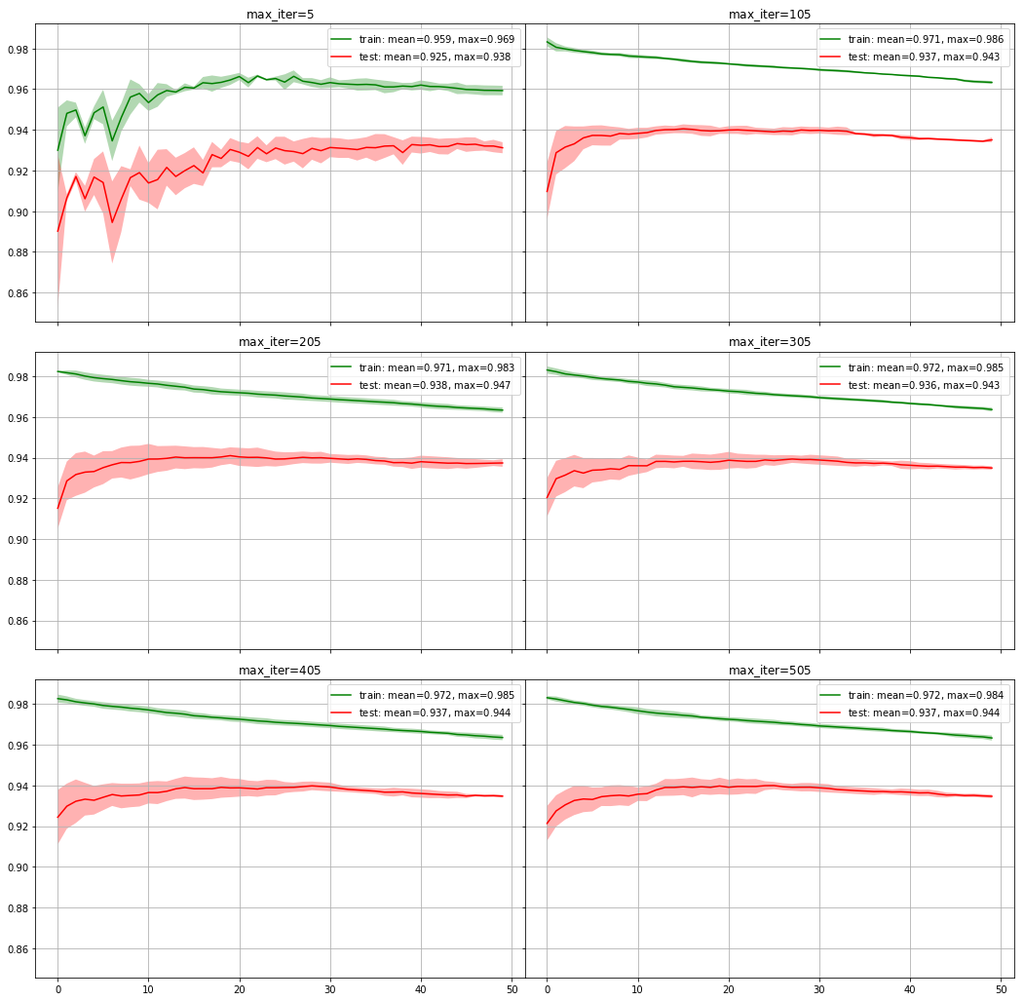

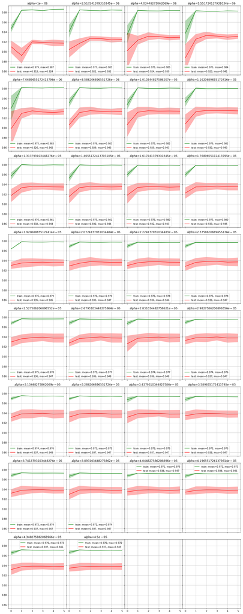

###### Процедура отрисовки кривых обучения

```python
# процедура рисует диаграммы результатов GridSearchCV
def plot_validation_curves_grid(param, grid_cv_results_, ncol=3):

    param_list = set(grid_cv_results_['param_' + param].data)
    nrows = int(ceil(len(param_list)/ncol))
    fig, axes = plt.subplots(nrows=nrows, ncols=ncol, figsize=(18, nrows*6), sharex=True, sharey=True,
                             gridspec_kw={'wspace':0, 'hspace':0.1})

    for idx, x in enumerate(sorted(param_list)):
        mask = grid_cv_results_['param_' + param].data == x
        train_mu, train_std = grid_cv_results_['mean_train_score'][mask], grid_cv_results_['std_train_score'][mask]
        valid_mu, valid_std = grid_cv_results_['mean_test_score'][mask], grid_cv_results_['std_test_score'][mask]

        train_line = axes.ravel()[idx].plot(train_mu, '-', color='green',
                                            label='train: mean=${0:.3f}$, max=${1:.3f}$'
                                            .format(train_mu.mean(), max(train_mu + train_std)))
        valid_line = axes.ravel()[idx].plot(valid_mu, '-', color='red',
                                            label='test: mean=${0:.3f}$, max=${1:.3f}$'
                                            .format(valid_mu.mean(), max(valid_mu + valid_std)))

        axes.ravel()[idx].fill_between(range(0,train_mu.shape[0]), train_mu - train_std, train_mu + train_std, edgecolor='none',
                         facecolor=train_line[0].get_color(), alpha=0.3)
        axes.ravel()[idx].fill_between(range(0,valid_mu.shape[0]), valid_mu - valid_std, valid_mu + valid_std, edgecolor='none',
                         facecolor=valid_line[0].get_color(), alpha=0.3)
        axes.ravel()[idx].legend()
        axes.ravel()[idx].set_title('{0}=${1}$'.format(param, x))
```

### Подготовка собственных выборок

При подготовке собственных выборок было использовано два подхода:

- измненение ширины окна
- измненение ограничения на максимальную продолжительность сессии

К каждой выборке также были добавлены четыре дополнительных реквизита, указанные выше.

Для каждого варианта выборки была выполнена следующая последовательность действий:

- поиск по сетке при помощи [GridSearchCV](http://scikit-learn.org/stable/modules/generated/sklearn.model_selection.GridSearchCV.html) по двум параметрам: **`alpha`** и **`max_iter`**
- обучение и расчет ROC AUC на отложенной выборке для **`best_estimator`** и **`peak_estimator`**
- кросс-валидация с расчетом ROC AUC для полной обучающей выборки для **`best_estimator`** и **`peak_estimator`**
- объединение **`best_estimator`** и **`peak_estimator`** при помощи [VotingClassifier](http://scikit-learn.org/stable/modules/generated/sklearn.ensemble.VotingClassifier.html)

#### Изменение ширины окна

Значения ширины окна были применены следующие: **`3, 5, 7, 8, 9`**. Точность прогноза на отложенной выборке и на кросс-валидации по полной выборке была максимальная при ширине окна 3 (здесь и ниже приводятся значения метрики ROC AUC):

- на отложенной выборке - 0.992245
- на кросс-валидации: train - 0.974144, test - 0.968112

Такой результат на отложенной выборке был логичен, т.к. размер выборки увеличивается при уменьшении ширины окна. Но результат на тестовой выборке оказался провальный - 0.91436.

По мере увеличения ширины окна точность прогноза на отложенной выборке и на кросс-валидации снижалась, а на тестовой выюборке увеличивалась. При ширине окна 9 результаты такие:

- на отложенной выборке - 0.984807
- на кросс-валидации: train - 0.969363, test - 0.0.949841
- на тестовой выборке - 0.94894

Таким образом, несмотря на больший размер выборки при малых значениях ширины окна, лучший результат достигнут при ширине окна 9. Этот эффект я связываю с тем, что при уменьении ширины окна хоть объектов и становится больше, но они становятся менее похожи на объекты тестовой выборки. К сожалению, для переформирования тестовой выборки данные в задании не предоставлены.

#### Изменение ограничения продолжительности сессии

Второй подход к формированию собственной выборки - ограничение продолжительности сессии. Были использованы продолжительности **`300, 600, 900`** секунд. ROC AUC на отложенной выборке на классификаторе с параметрами по умолчанию показал следующие результаты:

```
длина сессии - 10, лимит сессии - 300, CV ROC AUC - 0.7582, ROC AUC - 0.897279, время - 21.97
длина сессии - 10, лимит сессии - 600, CV ROC AUC - 0.7454, ROC AUC - 0.942931, время - 7.99
длина сессии - 10, лимит сессии - 900, CV ROC AUC - 0.7180, ROC AUC - 0.942366, время - 8.08
```

Лучшее значение на кросс-валидации у сессии длиной 300 секунд, на отложенной выборке - у сессии длиной 600 секунд. Работа с этими выборками осуществлялась по алгоритму, описанному выше. Результаты следующие:

| sample | ROC AUC | best_estimator | peak_estimator | VotingEnsemble |
| --- | --- | --- | --- | --- |
| 300 | valid | 0.98538 | 0.98531 | 0.98535 |
|  | CV train | 0.97176 | 0.97140 | 0.97158 |
|  | CV test | 0.94840 | 0.94841 | 0.94832 |
|  | **kaggle** | **0.94999** | **0.94972** | **0.94986** |
| 600 | valid | 0.97958 | 0.98064 | 0.98012 |
|  | CV train | 0.96364 | 0.96731 | 0.96560 |
|  | CV test | 0.94225 | 0.94335 | 0.94242 |
|  | **kaggle** | **0.94982** | **0.94950** | **0.95000** |

Лучний результат, и почетное **57 место**, принес вариант с выборкой, где продолжительность сессии ограничена 600 секундами, и применен VotingClassifier к best_estimator и peak_estimator. На эксперименты с выборкой, где продолжительность сессии ограничена 900 секундами, времени, увы, не хватило.

Вообще, этот вариант модификации выборки мне показался более походящим, т.к. медианная продолжительность сессии находтся в районе 30 секунд, со стандартным отклонением в пару минут, т.е. здесь небольшая модификация обучающей выборки ради увеличения количества объектов, не делает эти объекты сильно непохожими на объекты тестовой выборки, которую мы не изменяем.

## Многоклассовая классификация (применение Vowpal Wabbit)

Последним заданием финального проекта была задача многоклассовой классификации (400 классов). Для ее решения предлагалось сравнить результаты трех классификаторов: [LogisticRegression](http://scikit-learn.org/stable/modules/generated/sklearn.linear_model.LogisticRegression.html) и [SGDClassifier](http://scikit-learn.org/stable/modules/generated/sklearn.linear_model.SGDClassifier.html) с логистической регрессией из [scikit-learn](http://scikit-learn.org/stable/index.html), и one-against-all classifier с логистической регрессией из [Vowpal Wabbit](https://github.com/JohnLangford/vowpal_wabbit/wiki)

С учетом того, что классификация многоклассовая, и на такое большое количество классов, точность проноза существенно ниже бинарного случая. Результаты работы классификаторов приведены в таблице (valid - на отложенной выборке, test - на полной выборке)

| classifier | valid | test |
| --- | --- | --- |
| SGDClassifier | 0.291 | 0.175 |
| LogisticRegression | 0.363 | 0.199 |
| Vowpal Wabbit | 0.345 | 0.188 |

Лучший результат оказался у **`LogisticRegression`**, но время расчета слишком длительное - на моем ноутбуке 40 минут на полной выборке. **`Vowpal Wabbit`** - на втором месте, при этом время обучения на порядок быстрее - 40-50 секунд. Самым быстрым ожидаемо оказался **`стохастический градиентный спуск`** - обучается в пределах 10 секунд, но прогноз худший из трех классификаторов.

# Резюме

Мне оказалось сложно сформулировать четко какую-то бизнес задачу в прикладных терминах. Если очень общо, то это задачи анализа текстов, биоинформатика и т.п. То есть задачи, где имеется очень большое количество значений категориальных признаков.

Результатом работы доволен не вполне - кого может порадовать 57 место ;) но процессом удовлетворен полностью. Главное, что к окончанию я не оказался в тупике, без надежд улучшить результат. И вот на что не хватило времени:

- попробовать n-граммы при преобразовании TF-IDF
- попробовать еще какие-то классификаторы, и их объединение (попытки были, но очень беглые)
- попробовать LogisticRegression, хоть это и долго
- попробовать Vowpal Wabbit на бинарной классификации
- попытаться преобразовать тестовую выборку (поиграть с ограничением продолжительности сессии)
- подумать, что бы еще такое применить для решения задачи ;)

Думаю, что еще попробую что-то из этого в ближайшее время!

И немного о том, что тестировалось, но не вошло в итоговый отчет, т.к. не принесло результата (возможно, из-за недостаточного внимания к вопросу):

- [Стекинг от Александра Дьяконова](https://alexanderdyakonov.wordpress.com/2017/03/10/cтекинг-stacking-и-блендинг-blending)
- Понижение размерности при помощи [TruncatedSVD](http://scikit-learn.org/stable/modules/generated/sklearn.decomposition.TruncatedSVD.html):
  - обучение выборки пониженной размерности
  - добавление новых признаков (100 штук) к обучающей выборке

**И в заключение. Спасибо всем! Преподавателям - за науку, грызущим гранит - за поддержку и советы. До новых встреч!**